# Statistical Laboratory Exam - 18/1/21

Anahita Esfandiaryfard

# Data

```r
View(rock)
(?rock)
```

# Question 1

```r
summary(rock)
```

```
      area            peri            shape              perm         high.perm
 Min.   : 1016   Min.   : 308.6   Min.   :0.09033   Min.   :   6.30   0:24
 1st Qu.: 5305   1st Qu.:1414.9   1st Qu.:0.16226   1st Qu.:  76.45   1:24
 Median : 7487   Median :2536.2   Median :0.19886   Median : 130.50
 Mean   : 7188   Mean   :2682.2   Mean   :0.21811   Mean   : 415.45
 3rd Qu.: 8870   3rd Qu.:3989.5   3rd Qu.:0.26267   3rd Qu.: 777.50
 Max.   :12212   Max.   :4864.2   Max.   :0.46413   Max.   :1300.00
```

According to the result Area with 7487 has the most median

# Question 2

The following code will add the high.perm column and transform it into a factor:

```r
rock$high.perm <- factor(as.integer(rock$perm>median(rock$perm)))
```

we can check the results like below:

```r
levels(rock$high.perm)
```

```
[1] "0" "1"
```

And to see data in each group:

```r
summary(rock$high.perm)
```

```
 0  1
24 24
```

As the results shows there are 24 values in each group, because median divides the data in two equal parts

# Question 3

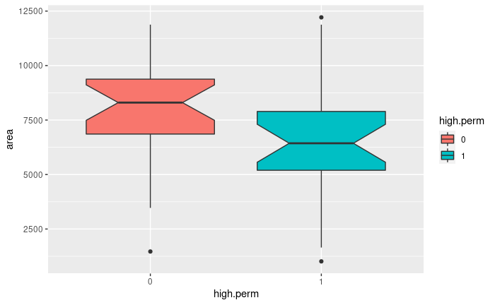

```r
library(ggplot2)
ggplot(rock, aes(x=high.perm, y=area, fill=high.perm)) +
  geom_boxplot(notch=T)
```

# Question 4

```r
(n_rice <- round(2*nrow(rock)**(1/3)))
```

```
[1] 7
```

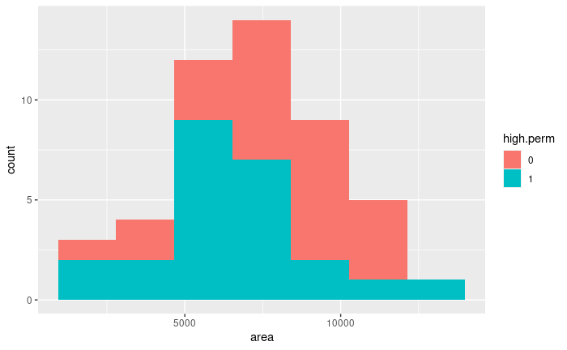

```r
ggplot(rock, aes(x=area, fill=high.perm)) +
  geom_histogram(bins=n_rice)
```

The histogram shows the same result as before as we can see here group 0 has more area than 1.

# Question 5

The following code computes the correlation matrix removing the last columns which is high.perm:

```r
(c <- cor(rock[-c(5)]))
```

```
            area       peri      shape       perm
area   1.0000000  0.8225064 -0.1821611 -0.3966370
peri   0.8225064  1.0000000 -0.4331255 -0.7387158
shape -0.1821611 -0.4331255  1.0000000  0.5567208
perm  -0.3966370 -0.7387158  0.5567208  1.0000000
```

```r
library(corrplot)
corrplot.mixed(c, plot=F)
```

```
Error in match.arg(plotCI) : 'arg' must be NULL or a character vector
```

# Question 6

The pair with the strongest correlation is area - peri. This is a strong positive correlation (0.82).

To check the corelation:

```r
cor.test(rock$area, rock$peri)
```

```
    Pearson's product-moment correlation

data:  rock$area and rock$peri
t = 9.8083, df = 46, p-value = 7.506e-13
alternative hypothesis: true correlation is not equal to 0
95 percent confidence interval:
 0.7025624 0.8970080
sample estimates:
      cor
0.8225064
```

# Question 7

```r
up.high.perm <- subset(rock, high.perm==1)
down.high.perm <- subset(rock, high.perm==0)
```

The mean of two samples is:

```r
mean(up.high.perm$peri)
```

```
[1] 1823.131
```

```r
mean(down.high.perm$peri)
```

```
[1] 3541.293
```

It looks like down high.perm has the most mean.

# Question 8

```r
t.test(up.high.perm$peri, down.high.perm$peri)
```

```
    Welch Two Sample t-test

data:  up.high.perm$peri and down.high.perm$peri
t = -5.1724, df = 45.703, p-value = 4.991e-06
alternative hypothesis: true difference in means is not equal to 0
95 percent confidence interval:
 -2386.918 -1049.405
sample estimates:
mean of x mean of y
 1823.131  3541.293
```

The p-value is below the significance level, so the difference between the means is actually statistically significant.

# Question 9

Let us fit the regressor:

```r
(reg <- lm(perm ~ area+peri+shape, rock))
```

```
Call:
lm(formula = perm ~ area + peri + shape, data = rock)

Coefficients:
(Intercept)         area         peri        shape
  485.61797      0.09133     -0.34402    899.06926
```

To check if regression is a good fit we use summary:

```r
summary(reg)
```

```
Call:
lm(formula = perm ~ area + peri + shape, data = rock)

Residuals:
    Min      1Q  Median      3Q     Max
-750.26  -59.57   10.66  100.25  620.91

Coefficients:
             Estimate Std. Error t value Pr(>|t|)
(Intercept) 485.61797  158.40826   3.066 0.003705 **
area          0.09133    0.02499   3.654 0.000684 ***
peri         -0.34402    0.05111  -6.731 2.84e-08 ***
shape       899.06926  506.95098   1.773 0.083070 .
---
Signif. codes:  0 ‘***’ 0.001 ‘**’ 0.01 ‘*’ 0.05 ‘.’ 0.1 ‘ ’ 1

Residual standard error: 246 on 44 degrees of freedom
Multiple R-squared:  0.7044,    Adjusted R-squared:  0.6843
F-statistic: 34.95 on 3 and 44 DF,  p-value: 1.033e-11
```

# Question 10

First lets plot the residual of current regression:

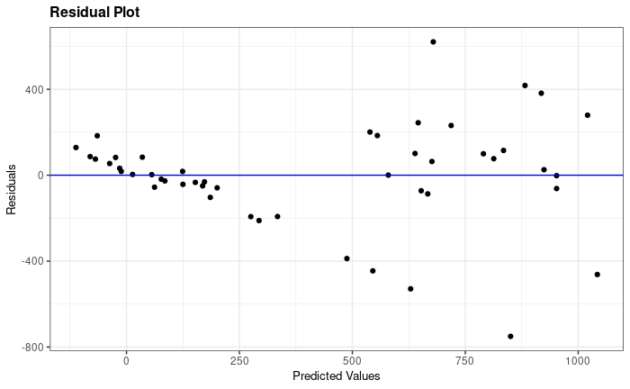

```r
library(ggResidpanel)
resid_panel(reg, plots="resid")
```

Now To do a backward elimination first we need to do the regression from all variables in the dataset:

```r
reg1 <- lm(perm ~ area+peri+shape, rock)
summary(reg1)
```

```
Call:
lm(formula = perm ~ area + peri + shape, data = rock)

Residuals:
    Min      1Q  Median      3Q     Max
-750.26  -59.57   10.66  100.25  620.91

Coefficients:
             Estimate Std. Error t value Pr(>|t|)
(Intercept) 485.61797  158.40826   3.066 0.003705 **
area          0.09133    0.02499   3.654 0.000684 ***
peri         -0.34402    0.05111  -6.731 2.84e-08 ***
shape       899.06926  506.95098   1.773 0.083070 .
---
Signif. codes:  0 ‘***’ 0.001 ‘**’ 0.01 ‘*’ 0.05 ‘.’ 0.1 ‘ ’ 1

Residual standard error: 246 on 44 degrees of freedom
Multiple R-squared:  0.7044,    Adjusted R-squared:  0.6843
F-statistic: 34.95 on 3 and 44 DF,  p-value: 1.033e-11
```

From the result we can see that shape is not really relevant now we should eliminate the parameter with highest p value which in this case is shape also.

```r
reg1 <- lm(perm ~ area+peri, rock)
summary(reg1)
```

```
Call:
lm(formula = perm ~ area + peri, data = rock)

Residuals:
    Min      1Q  Median      3Q     Max
-571.26  -63.61   -1.70  111.35  615.58

Coefficients:
             Estimate Std. Error t value Pr(>|t|)
(Intercept) 696.68829  107.00334   6.511 5.43e-08 ***
area          0.10639    0.02406   4.421 6.14e-05 ***
peri         -0.38995    0.04511  -8.645 4.05e-11 ***
---
Signif. codes:  0 ‘***’ 0.001 ‘**’ 0.01 ‘*’ 0.05 ‘.’ 0.1 ‘ ’ 1

Residual standard error: 251.8 on 45 degrees of freedom
Multiple R-squared:  0.6833,    Adjusted R-squared:  0.6692
F-statistic: 48.54 on 2 and 45 DF,  p-value: 5.823e-12
```

All variables are now statistically relevant. The backward elimination process is finished. We can now conclude showing the residual plot:

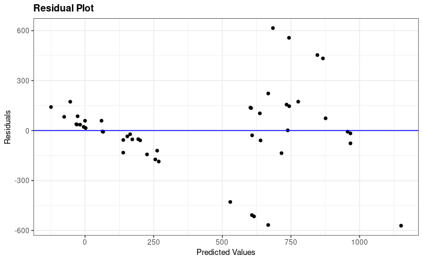

```r
library(ggResidpanel)
resid_panel(reg1, plots="resid")
```